# TPP-P2-V01022512-Isaac-Preyser

$\def\ket#1{|#1\rangle}$ $\def\bra#1{\langle#1|}$

```python
# Hausi's email: hausimuller@gmail.com
# Quantum Composer: quantum.cloud.ibm.com/composer

# notebook imports
import qiskit
from qiskit_ibm_runtime import QiskitRuntimeService
import os

# load environment variables from .env file
from dotenv import load_dotenv
load_dotenv()

# load Qiskit API token from .env file
QISKIT_API_TOKEN = os.getenv("QISKIT_API_TOKEN")
QiskitRuntimeService.save_account(token=QISKIT_API_TOKEN, overwrite=True)

# import qutip; for modelling quantum systems
import qutip
```

The goal of this Term Portfolio Project (TPP) is to document your learning journey into the realm of Quantum Computing by developing a Jupyter Notebook Portfolio.

First and foremost, this document is for you to reflect regularly on your learning journey. Secondly, it is intended for your instructors and teaching assistants to gauge your progress in understanding the topics being discussed in this course.

The Portfolio Term Project should be developed incrementally — with weekly contributions. The TPP consists of two parts. The first part should be approximately 5-7 pages (i.e., printing Jupyter Notebook as PDF pages). The second part must include the first part at the beginning of the document -- that is, simply extend the Part 1 Jupyter Notebook to develop the second part. Thus, the final Jupyter Notebook that includes both parts should be approximately 18-20 pages.

For Part 1, you are to document the following aspects of your Quantum computing journey, and also your experience learning the functionality and use of Jupyter Notebooks. Here are some questions you can answer for Part 1 of your TPP.

1. How did you get up to speed in basic linear algebra (e.g., Euler formula, complex plane, linear transformations or operators, eigenvectors and eigenvalues), including which resources you consulted in this process?

> As I am early(ish) into my degree program, I took linear algebra not too long ago (2 years prior to this course). I also took PHYS223 two semesters ago, which served as a good introduction to the physics (and maths) behind QIS, and further solidified my linear algebra skills. For these reasons it took less time to get back "up to speed".

> Additionally, the [Xanadu Quantum Codebook](https://pennylane.ai/codebook) helped significantly.
2. How did you get started in documenting linear algebra formulas (e.g., Euler formula or matrices) using LaTeX Markdown in Jupyter Notebooks? Develop your own cheat sheet of the quantum computing formulas and Dirac notation to ease assignment typesetting.

> I actually used Jupyter Notebooks for PHYS223 as well, so I was quite familiar with common $\LaTeX{}$ notation used in QIS.

### Commonly used notation:

`\bra{[some symbol]}`: Pretty self-explanatory. creates a Bra.

`\ket{[some symbol]}`: As above. Creates a ket.

`\begin{bmatrix} a & b \\ c & d \end{bmatrix}`: Creates a 2x2 matrix with elements a,b,c,d. This can be adapted to any size for states or operators.

`\otimes`: Creates a tensor product symbol.

`\dagger`: Creates a dagger symbol, used for Hermitian conjugates.

`\oplus`: Creates a plus symbol inside a circle, used for the XOR operation.

`\psi, \phi, \theta, \alpha, \beta, \gamma`: Commonly used Greek letters for states and angles. Capitalization of the first letter in the code yields the capitalized version of the letter in the output.

3. How did you get started running your first quantum circuits using IBM Qiskit and Xanadu Pennylane Jupyter Notebook platforms?

> I prefer IBM Qiskit (as I have previous experience there) and used it's tools extensively to model and simulate circuits. Last year we ran a number of circuits on real `IBM-Heron` processors (usually `ibm-sherbrooke` or `ibm-marrakesh`.) If you have a LaTeX installation, you can make Qiskit output a beautiful circuit in LaTeX format and even have it match standard notation by flipping the order of the qubits:

```
# obviously one should define circuit earlier by using a Qiskit.QuantumCircuit object first.

circuit.draw(output="latex", reverse_bits="True")
```

> For PennyLane, I used Xanadu's [coding challenges](https://pennylane.ai/challenges) to experiment with the platform and get a feel for how it works, intuitively. I found the documentation to be quite good, and the challenges were a fun way to get started.

> To manage all of these libraries and their dependencies, I used Anaconda to create a virtual environment for this course. This allowed me to keep all of the necessary libraries and tools organized and easily accessible without interfering with other projects or courses I am working on. I also created a startup scrit that hooks into the `conda activate` command to automatically activate the environment when I start a new Jupyter Notebook session for this course, allowing me to access my system-wide LaTeX installation for rendering mathematical formulas in my notebooks.
4. How would you motivate other students to join the journey into quantum computing given the motivational materials presented in class and found in the references? Your answers to this question will likely evolve during this course. Revisit regularly this quesion.

The answer to this question definitely depends on the student one is talking to-- Quantum Computing has many applications (and therefore reasons for study).

As a SENG major, I found the applications of Shor's Algorithm to be most interesting- as cybersecurity and cryptography are elements of my degree program that I found to be extremely interesting.

A theoretical CSC major may find Grover's Algorithm most interesting, observing the $O(\log{n})$ to $O(\sqrt{n})$ time complexity speedup for search most interesting.

Science majors may find other applications areas more useful, like molecular modeling, or VQEs for math/physics fields.

Furthermore the foundational sciences behind quantum computation might prove to be the most motivating factor, especially for students interested in photonics or dealing with particles near absolute zero.

5. Which algorithm is your favourite quantum algorithm so far? In my studies I found Shor's algorithm to be my favourite so far- Dr. De Sousa's explanation in my previous studies really showed the elegance of the algorithm, and being able to test out the algorithm on real software proved to be really cool.
6. What was the most challenging part in understanding Grover's algorithm?

> Note that we haven't actually covered Grover's algorithm yet and we never covered it in PHYS223- so I can't really comment on this yet.

> To be completely transparent, I don't have a good understanding of Grover's algorithm yet, but I am looking forward to learning about it in the coming weeks. I have heard that it is a very powerful algorithm for search problems, and I am excited to see how it works and what makes it so efficient compared to classical algorithms.
7. (Required) What are your personal insights, aha moments, and epiphanies you experienced in the first part of this course?

> Jan 20 (Insight): I realize that I need to review Clifford Gates in a more in-depth manner. It seems I haven't looked at those enough.

> Feb 9 (Aha moment): Although I had a functional understanding of the tensor product, I was quite out of practice working with the tensor product (especially in Dirac notation) and by "refreshing" my knowledge, I actually learned a ton of properties of both the tensor and Kronecker products that I had never known.

> To do this, I began with Nielsen and Chuang's introduction [2] to the tensor product (section 2.17), and supplemented further with an assortment of linear algebra notes from various universities I found on the internet. [3]
8. (Required) How did you experience Generative AI as a learning tool for this course? Record your Generative AI prompts and contexts for Basic Quantum Terms, Complex Linear Algebra, Quantum Algorithms, Python, Qiskit, and PennyLane inquiries for easy recall. Use the same line item or project in your genAI engine (e.g., ChatGPT, Google Gemini, Perplexity, or others) to build up the "quantum context".

> I relied on a combination of Claude Opus v4.6 (via Github Copilot, in my VSCode IDE) and Gemini Pro (via NotebookLM) for my genAI needs. I typically used Claude for quick, in-class technical questions (while I wrote my notes in VSCode) and used Gemini for more in-depth questions that required a more detailed response. The nice thing about Claude is that it is integrated into my coding environment, so I can quickly ask questions about syntax or concepts while I am working on my code, and it scans my existing notes and documentation to provide contextually relevant answers. Gemini, on the other hand, is great for more complex questions that require a deeper understanding of the material, and I can use it to build up a more comprehensive "quantum context" over time by feeding it my notes and previous interactions.

> For Gemini, using the NotebookLM platform was particularly helpful in building up this "quantum context" because it allows me to easily organize and access all of my notes, prompts, textbooks, and other resources in one place. This way, I can quickly refer back to previous discussions or information when I have new questions, and it helps me to see connections between different topics as I build up my understanding of quantum computing. Furtermore the model prioritizes using information already provided in the notebook, so I can be sure that the answers I get are consistent with my existing knowledge and notes. I would often use Gemini to help me understand physics concepts referred to in Nielsen and Chuang, and then use that understanding to inform my coding in Qiskit or PennyLane.

Citations and references. The contents of your notebook portfolio project must be your own work. If you reference the work of others (including information found on the web or using genAI tools), include full citations in a bibliography at the end of your document.

# Week 2 (Lecture 3-4)

Introduction to 1-qubit systems.

Recall Euler's Identity:

$$ e^{i\pi{}} + 1 = 0 $$

Which in the general case is Euler's Formula:

$$ e^{i\theta} = \cos{\theta} + i \sin{\theta} $$

## Classical vs. Quantum Computing

Quantum computing is a completely different model of computation.

A key difference is that qubits can be in *superposition*- that is, data can exist on a spectrum anywhere from $\ket{0}$ to $\ket{1}$.

It is based on linear algebra, rather than boolean algebra in the classical realm. States may be ambiguous, due to entanglement and importantly, interference.

> Noise can often be characterized statistically by running a circuit many times and sampling, but interference itself is something we intentionally engineer inside the algorithm.

Quantum algorithms explore superposed computational paths and then use interference to bias the final measurement outcomes. The gates themselves are unitary and deterministic; the randomness appears when we measure.

## Basic Gates

$\ket{\phi}$ Gate: Initializes qubit to a given state, described by $\phi$.

> Note that this gate is not physically realizable on real quantum hardware, but is useful for simulation.

Hadamard (H) Gate: Puts a qubit into superposition. Note the definition of Hadamard at [IBM Quantum Learning](https://quantum.cloud.ibm.com/docs/en/api/qiskit/qiskit.circuit.library.HGate)

$$ H = \frac{1}{\sqrt{2}} \begin{bmatrix} 1 & 1 \\ 1 & -1 \end{bmatrix} $$

*Note:* The Hadamard gate is a LINEAR operator. Therefore we can take advantage of the properties of linearity, which is especially useful when dealing with states in superposition.

CNOT: Depending on the value of the control-bit, this will perform a NOT operation (Pauli-X matrix) on the target qubit.

Measurement: Collapses the qubit and measures it, and outputs to a classical bit.

## Matrix Notation

Dirac notation is a way of doing "short-hand" for large vectors. This simplifies working with matrices.

## Bra-Ket Notation

[Bra-Ket notation](https://en.wikipedia.org/wiki/Bra%E2%80%93ket_notation) is the standard way of communicating Quantum Information.

### Computational Basis

In quantum mechanics, $\ket{0}$ and $\ket{1}$ are the fundamental, orthogonal states of a qubit, analogous to $0$ and $1$ of a classical bit.

They form the building blocks for any more complex quantum state.

$$ \ket{0} = \begin{bmatrix} 1 \\ 0 \end{bmatrix}, \quad \ket{1} = \begin{bmatrix} 0 \\ 1 \end{bmatrix} $$

## So what is a Bra and a Ket?

A "Ket" $\ket{\psi}$ is a column vector, representing a quantum state. A "Bra" $\bra{\psi}$ is the conjugate transpose of a Ket, represented as a row vector.

The Ket captures all information about a quantum state, while the Bra is used in operations like inner products and outer products.

### Conjugate Transpose

The conjugate transpose (or Hermitian transpose, notated by $\dagger$) of a matrix is obtained by taking the transpose of the matrix and then taking the complex conjugate of each element — that is, changing the sign of the imaginary part.

> To do this, replace every complex number in the vector with it's complex conjugate (i.e., change the sign of the imaginary part), then transpose the vector (i.e., convert rows to columns and vice versa).

$$ \text{If } \ket{\psi} = \begin{bmatrix} a + ib \\ c + id \end{bmatrix}, \text{ then } \bra{\psi} = \begin{bmatrix} a - ib & c - id \end{bmatrix} $$

## Inner Product

The inner product (or dot product) of two quantum states $\ket{\phi}$ and $\ket{\psi}$ is denoted as $\langle \phi | \psi \rangle$.

It is calculated like a dot product, and results in a scalar.

> These products are often referred to as expectation values.

### Applications

The inner product can be interpreted in many ways in Quantum Mechanics:

- **Quantum Overlap**: Measures the similarity (or overlap) between two quantum states. If $|\langle \phi | \psi \rangle|^2 = 1$, the states are identical; if $|\langle \phi | \psi \rangle|^2 = 0$, they are orthogonal (completely distinct).
- **Probability Amplitudes**: In measurement, the inner product $\langle i | \psi \rangle$ gives the probability amplitude of measuring state $\ket{\psi}$ in basis state $\ket{i}$. The probability is then $|\langle i | \psi \rangle|^2$.
- **Expectation Values**: Computing the expected measurement outcome of an observable $\hat{O}$ in state $\ket{\psi}$ is given by $\langle \psi | \hat{O} | \psi \rangle$.
- **Orthonormality**: Used to verify that basis states are orthonormal: $\langle i | j \rangle = \delta_{ij}$ (Kronecker delta).

## Outer Product

The reverse order produces a matrix (often used as an operator):

$$ \ket{\psi}\bra{\phi} = \begin{bmatrix} \psi{}_1 \\ \psi{}_2 \end{bmatrix} \begin{bmatrix} \phi{}_1^{*} & \phi{}_2^{*} \end{bmatrix} $$

### Applications

- **Projection Operators**: The outer product $\ket{\psi}\bra{\psi}$ creates a projection operator that projects any state onto $\ket{\psi}$. This is fundamental in quantum measurement theory.
- **Density Matrices**: A mixed quantum state can be represented as $\rho = \sum_i p_i \ket{\psi_i}\bra{\psi_i}$, where $p_i$ are classical probabilities.
- **Gate Construction**: Many quantum gates can be expressed using outer products. For example, the phase flip on $\ket{0}$ can be written as $I - 2\ket{0}\bra{0}$.
- **Completeness Relation**: The identity operator can be decomposed as $I = \sum_i \ket{i}\bra{i}$ for a complete orthonormal basis $\{\ket{i}\}$.

## Superposition

Unlike classical bits, a qubit can exist in a superposition of $\ket{0}$ and $\ket{1}$, simultaneously. This is a probablilistic combination of all possible states until measured. (Think a linear combination of states.)

$$ \ket{\psi} = \alpha{} \ket{0} + \beta{}\ket{1} \qquad{} \alpha{}, \beta{} \in{} \mathbb{C} $$

Note that $\alpha{}$ and $\beta{}$ are **complex amplitudes**, and are NOT probabilities.

Superposition is the physical interpretation of a linear combination.

- The qubit is not in state $\ket{0}$ or in state $\ket{1}$.
- It instead exists in a **coherent combination** of both basis states.
- Interference between amplitudes is possible (this enables many quantum algorithms to amplify correct answers)

> Superposition enables quantum parallelism and interference, but is not inherently randomness.

## Born Rule

The Born rule connects the quantum state to measurement outcomes:

$$ P(0) = |\alpha|^2, \qquad P(1) = |\beta|^2 $$

- Measurement collapses the state to a basis state
- Probabilites come from squared magnitudes.
- It is important to ensure probabilites sum to 1.

We often want $ |\alpha|^2 + |\beta|^2 = 1$.

Alternatively,

$$ |\alpha|^2 + |\beta|^2 = \alpha \alpha^* + \beta \beta^* = 1 $$

Note how * denotes the complex conjugate of each value.

> This is why superpositions often have square-rooted magnitudes.

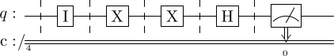

```python
from qiskit import QuantumRegister, ClassicalRegister, QuantumCircuit
from numpy import pi

qreg_q = QuantumRegister(1, 'q')
creg_c = ClassicalRegister(4, 'c')
circuit = QuantumCircuit(qreg_q, creg_c)

circuit.barrier(qreg_q[0])
circuit.id(qreg_q[0])
circuit.barrier(qreg_q[0])
circuit.x(qreg_q[0])
circuit.barrier(qreg_q[0])
circuit.x(qreg_q[0])
circuit.barrier(qreg_q[0])
circuit.h(qreg_q[0])
circuit.barrier(qreg_q[0])
circuit.measure(qreg_q[0], creg_c[0])

circuit.draw(output='latex', style='default')
```

Let's talk about gates, and what they do.

## Identity matrix (I-Gate)

This applies the identity matrix to the state, appling the operation $I\ket{\psi}$ for some arbitrary state.

## NOT Gate (Pauli-X Gate)

This applies the Pauli-X matrix to the state, inverting it's state.

$$ X = \begin{bmatrix} 0 & 1 \\1 & 0 \end{bmatrix} $$

## H Gate (Hadamard Gate)

This applies the Hadamard Matrix to the state as a unitary operator. The Hadamard Matrix is defined as: $$ H = \frac{1}{\sqrt{2}} \begin{bmatrix} 1 & 1 \\ 1 & -1 \end{bmatrix} $$ This puts a single qubit into an equal superposition in the computational basis.

Recall:

$$ \ket{0} \xrightarrow{H} \ket{+} \\ \ket{1} \xrightarrow{H} \ket{-} \\ $$

## Key Definitions

- Gate Time Definition: Time required to apply a single quantum gate operation
- Optimization Balance: Balance operational speed against error rates and decoherence.
- Decoherence Risk: Like any physical system, the QPU wants to return to it's state of least entropy. This is fundamentally bad for quantum computers, as it means the data we have stored will become unintelligible- as we have lost our information. (Usually a quantized energy level has entered an undefined energy level, or some other physical phenomena in other implementations of quantum systems)

This means we can lose our information stored in the system. This is further exacerbated by the introduction of additional quantum gates in our system, as they inherently introduce additional quantum noise into our states.

# Unitary Operations

Unitary operations are incredibly important to quantum computing. Each operator is reversible.

For any unitary matrix $U$:

$$ UU^{\dagger} = I $$

- We observe the conservation of probability (that is the total probability remains exactly 1),
- We observe that all unitary operations (hence all quantum operations) can be undone.

To check if a matrix is unitary, verify that matrix multiplicaiton with it's complex conjugate yields the identity matrix.

In short, Unitary Matrices **preserve probabilites** and are **reversible**.

> Note that matrices are linear operators. Therefore all properties of linearity apply.

## Why are matrices called operators?

Matrices act on vectors to produce new vectors - acting exactly like functions that transform inputs to outputs.

We can apply these operations sequentially, as defined already in matrix arithmetic.

Using matrices as operators unlocks eigenvalue analysis, diagonalization and spectral theory - tools for solving complex problems.

# Week 3 (Lecture 5/6)

This week we have our first quiz on the basics of Quantum Computation (Jan. 20). Review Bra-Ket, matrix mult, complex analysis, basic gates (hadamard, pauli, etc.) and transformations on the computational basis.

This week we should be jumping into quantum computation a bit further, and maybe see our first algorithm (likely Shor) soon.

## Lecture 5

In this lecture we will begin introducing multi-qubit modelling, and introduce the tensor product. We might get into Hilbert spaces in the lecture too.

Four important states on the Bloch sphere:

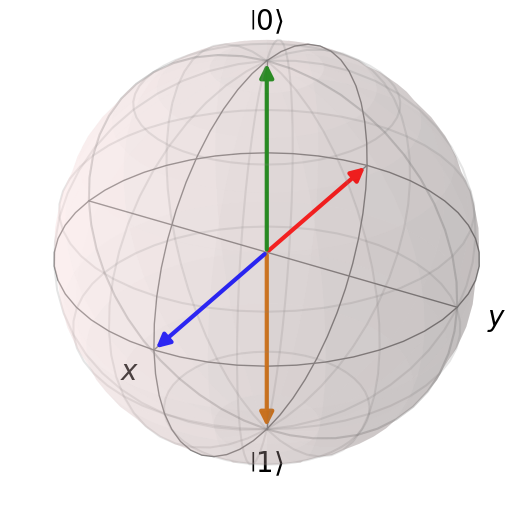

```python
ket_zero = qutip.basis(2, 0)  # ground state |0>, green arrow
ket_one = qutip.basis(2, 1)  # excited state |1> , orange arrow
ket_plus = qutip.basis(2, 0).unit() + qutip.basis(2, 1).unit()  # normalized superposition state (|0> + |1>)/sqrt(2) \equiv |+>, blue arrow
ket_minus = qutip.basis(2, 0).unit() - qutip.basis(2, 1).unit()  # normalized superposition state (|0> - |1>)/sqrt(2) \equiv |->, red arrow

bloch = qutip.Bloch()  # visualize the Bloch sphere
bloch.add_states([ket_zero, ket_one, ket_plus.unit(), ket_minus.unit()])
bloch.show()
```

## Key States

The Bloch sphere above has two computational bases mapped upon it. They are:

### Computational Basis: $\ket{0}$ (Green Arrow), $\ket{1}$ (Orange Arrow)

This is the *Z-basis*.

### Hadamard Basis: $\ket{+}$ (Blue Arrow), $\ket{-}$ (Red Arrow)

This is the *X-basis*.

# Y-basis

$$ \ket{+Y} = \frac{1}{\sqrt{2}} \left(\ket{0} + i\ket{1} \right) $$

$$ \ket{-Y} = \frac{1}{\sqrt{2}} \left(\ket{0} - i\ket{1} \right) $$

## Matrices

Again, matrices are linear operators, where $M_{n,m}(\mathbb{C})$ is the set of all $n \times m$ complex matrices.

Some matrices serve as quantum (logic) gates.

> Quantum gates are $ n \times n$ complex matrices, and are *Euclidean Norm Preserving*.

> Q: What does *Euclidean Norm Preserving* mean? A: Review this article).

> A (after review): The Euclidean Norm, on the complex plane is just the *modulus* of the number. That is, the distance between two vectors remains unchanged after transformation via the unitary. See this [article](https://en.wikipedia.org/wiki/Isometry) for further details on the requirement for isometry.

If $U$ is unitary, then:

- $U^\dagger{} = U^{-1}$

> See slide 27 for more.

### Operations

- Complex conjugate $A^*$: $$ (A^*)_{ij} = (A_{ij})^* $$
- Transpose $A^T$: $$ (A^T)_{ij} = A_{ji} $$

> review L05 slides 23 and 24 for further operations.

### Properties

In general Commutative property does not hold! $A \cdot{} B \neq{} B \cdot{} A$

- Associativity: $ (AB)C = A(BC) = ABC $
- Distributive Property: $ A(B+C) = AB + AC$
- Distributive Property: $ (A+B)C = AC + BC $
- Commutativity of scalars: $ \lambda{} A(B) = A(\lambda{} B)$, where $\lambda \in \mathbb{C}$.

## Adjoint or Inverse Operations

Some quantum gates can cancel themselves when applied twice in a row. Some examples include the pauli gates, and the H gate.

A key mathematical term for these gates is that they satisfy the [Involutory Property](https://en.wikipedia.org/wiki/Involutory_matrix).

> Verify this later by manually computing the matrix represenations, where $ U \cdot U = I$, where each $U$ represents some pauli matrix, or a hadamard matrix.

## Hermitian Operators

> Will be covered next class (L06).

> The below extract comes from [Wikipedia](https://en.wikipedia.org/wiki/Hermitian_adjoint):

Hermitian Operators, (also called Hermitian Adjoint) are special linear operators that satisfy the following properties:

1. Involutivity: $A^{**} = A$
2. If $A$ is invertible, then so is $A^{*}$, with $(A^{*})^{-1} = (A^{-1})^*$.
3. Conjugate Linearity applies: a. $(A+B)^{*} = A^* + B^*$ b. $(\lambda{} A)^{*} = \bar{\lambda}A^{*}$, where the bar represents the complex conjugate of $\lambda$.
4. "Anti-distributivity": $(AB)^* = B^{*}A^{*}$

It's also important to note that Hermitian Operators only have real eigenvalues-- and have a complete set of orthonormal eigenvectors. (Keep this in mind, because we can use this property to quickly disprove whether a given linear operator is hermitian.)

## Pauli Matrices

Each of the pauli gates $X$, $Y$, and $Z$ correspond with a rotation over it's corresponding axis on the Bloch sphere.

We can use these to generate arbitrary rotation operators $R_{n \in \{X,Y,Z,\phi{}\}}(\theta)$, where $\phi{}$ corresponds to ANY arbitrary axis in the Bloch sphere.

> PHYS223 A3 should contain some review problems on this topic.

# Arbitrary Rotations

The below equation shows that, for any arbitrary normalized axis $\hat{n}$, we can perform a rotation around it, by generating a unitary operator, denoted $R_{\hat{n}}(\theta{})$. Note that $\vec{\sigma_{n}}$ denotes the vector definition for the axis $\hat{n}$:

> The below excerpt is adapted from my previous coursework for PHYS223:

**a)** The identity is resolved as follows:

$$ \begin{align} R_{\hat{n}}(\theta{}) &= e^{-i \frac{\theta{}}{2}\hat{n}\cdot{}\vec{\sigma{}}} \tag{Given by (1)} \\ &\equiv{} \sum{}_{k = 0}^{\infty{}} \left(\frac{\left(i \frac{\theta}{2} \vec{\sigma_{n}} \right)^{k}}{k!} \right) \tag{via the Maclaurin series expansion of $e^x$.} \\ &\equiv{} \sum{}_{k = 0}^{\infty{}} \left(\frac{\left(i \frac{\theta}{2} \vec{\sigma_{n}} \right)^{(2k)}}{(2k)!} \right) + \sum{}_{k = 0}^{\infty{}} \left(\frac{\left(i \frac{\theta}{2} \vec{\sigma_{n}} \right)^{(2k+1)}}{(2k + 1)!} \right) \tag{splitting into even and odd sums.} \\ \end{align} $$

As $\vec{\sigma{}_n}$ is a unit vector, we know that $\vec{\sigma{}_n}^2 = 1$ (This is because any unit vector can be formed as a linear combination of $\sigma_x, \sigma_y, \sigma_z$). (We also use the properties of $i$ to simplify further.) Therefore, we can simplify the Maclaurin series:

$$ \begin{align} &\equiv{} \sum{}_{k = 0}^{\infty{}} \left(\frac{\left((-1)^{k} \left(\frac{\theta}{2}\right)^{2k} \right)}{(2k)!} \cdot I \right) + \sum{}_{k = 0}^{\infty{}} \left(\frac{\left(-i (-1)^k \left(\frac{\theta}{2}\right)^{2k + 1} \right)}{(2k + 1)!} \cdot{} \vec{\sigma_{n}} \right) \\ &\equiv{} \cos{\frac{\theta{}}{2}} \cdot{} I - i \sin{\frac{\theta}{2}} \cdot \vec{\sigma_n} \qquad{} \tag{By expressing the Maclaurin series in closed form.} \end{align} $$ **b)** To prove that $R_{\hat{n}}(\theta{})$ is unitary, we must show that $R_{\hat{n}}(\theta{})^{\dagger} = R_{\hat{n}}(\theta{})^{-1}$, which implies that $R_{\hat{n}}(\theta{})^{\dagger} \cdot R_{\hat{n}}(\theta{}) = I$.

Hence, we must resolve the identity:

First, we have that $R_{\hat{n}}(\theta{})^{\dagger} = \left(\cos{\frac{\theta{}}{2}} \cdot{} I - i \sin{\frac{\theta}{2}} \cdot \vec{\sigma_n} \right)^{\dagger} = \cos{\frac{\theta{}}{2}} \cdot{} I + i \sin{\frac{\theta}{2}} \cdot \vec{\sigma_n}$.

This holds as both the identity and the Pauli matrices are Hermitian.

Next, we have that $R_{\hat{n}}(\theta{})^{\dagger} \cdot R_{\hat{n}}(\theta{}) = \left(\cos{\frac{\theta{}}{2}} \cdot{} I + i \sin{\frac{\theta}{2}} \cdot \vec{\sigma_n} \right) \cdot \left(\cos{\frac{\theta{}}{2}} \cdot{} I - i \sin{\frac{\theta}{2}} \cdot \vec{\sigma_n} \right) = \cos^{2}{\frac{\theta{}}{2}} \cdot{} I + \sin^{2}{\frac{\theta}{2}} \cdot{} I = I$.

As we have just resolved the identity, we have shown that $R_{\hat{n}}(\theta{})$ is unitary.

Next, we can show that $R_{\hat{n}}(\theta{})^\dagger = R_{\hat{n}}(-\theta{})$.

This may be achieved by subbing in $-\theta$ into the expression for $R_{\hat{n}}(\theta{})$.

$$ \begin{align} R_{\hat{n}}(-\theta{}) &= \cos{\frac{-\theta{}}{2}} \cdot{} I - i \sin{\frac{-\theta}{2}} \cdot \vec{\sigma_n} \\ &= \cos{\frac{\theta{}}{2}} \cdot{} I + i \sin{\frac{\theta}{2}} \cdot \vec{\sigma_n} \\ &= R_{\hat{n}}(\theta{})^{\dagger} \end{align} $$

# 2-qubit systems

These systems consist of 2 qubits instead of just one. $$ \ket{\psi} = \ket{\phi{}_1} \otimes \ket{\phi{}_2} = \ket{\phi{}_1 \phi{}_2} $$

This allows us to use controlled (mutli-qubit) gates, like CNOT.

As an example:

$$ \ket{\psi{}_1} = \alpha{}\beta{}\ket{10} = \alpha{}\ket{1} \otimes \beta{}\ket{0} = \alpha{}\begin{bmatrix} 0 \\ 1 \end{bmatrix} \otimes \beta{}\begin{bmatrix} 1 \\ 0 \end{bmatrix} = \alpha{}\beta{}\begin{bmatrix} 0 \cdot \begin{bmatrix} 1 \\ 0 \end{bmatrix} \\ 1 \cdot \begin{bmatrix} 1 \\ 0 \end{bmatrix} \end{bmatrix} = \alpha{}\beta{}\begin{bmatrix} 0 \\ 0 \\ 1 \\ 0\end{bmatrix} $$

Therefore we can observe that Dirac notation is a short-hand format for tensor-product form, where a bitstring within a dirac state is equal to each individual bit being tensor-multiplied with each surrounding bit in order.

$$ \ket{abc} = \ket{a} \otimes \ket{b} \otimes \ket{c} $$

## CNOT (among other multi-qubit gates)

Multi-qubit gates are larger than $2 \times 2$ matrices. This is because they operate on vectors of a higher dimensionality, and therefore must be larger to accomodate this. Given $n$ qubits to operate on, they will be of size $2^n \times 2^n$.

In general, if we are repeating the same gate $n$ times, we can use the notation: $$ U^{\otimes n} = U \otimes U \otimes U \otimes \dots \otimes U $$

> Review PHYS 223 notes for reference on designing custom multi-qubit gates.

# Lecture 6

## Interference

Amplitudes can interfere constructively or deconstructively, because they are complex numbers.

Constructive: Amplitudes with the same phase add together and increase the probability. Deconstructive: Amplitudes with opposing phases subtract and reduce the probability.

(This kind of works like the summation of sinusoidal functions)

## Entanglement

Qubits that should appear independent often influence other (entangled) qubits when they are affected. This means we shouldn't consider independent probabilities, but instead calculate **probability distributions**.

> Changing the direction of one qubit changes all the dependent probabilities.

# Lecture 7

> [Assignment 1](https://app.crowdmark.com/student/courses/spring-2026-csc-557-seng-457-a01-a02-x) is posted: it is due Feb. 9.

Helpful Definition: $U$ Gate, which can be defined as: $U \ket{\phi} = YH\ket{\phi}$. These gates perform the following operation:

$$ U(\theta, \phi, \lambda) = P(\phi) R_Y(\theta) P(\lambda) = e^{i\frac{\phi + \lambda}{2}} R_Z(\phi) R_Y(\theta) R_Z(\lambda). $$

This gate operates as a generic rotation function on one qubit.

## Creating a Simple Quantum Circuit (Qiskit)

```python
# Python function to create a simple circuit with one qubit
from qiskit import QuantumCircuit

def create_bell_circuit() -> QuantumCircuit:
    # initialize a quantum circuit with 2 qubits
    qc = QuantumCircuit(2)
    # apply a Hadamard gate on the first qubit
    qc.h(0)

    # apply a CNOT gate with the first qubit as control and the second as target
    qc.cx(0, 1)
    return qc

def print_circuit(qc: QuantumCircuit) -> None:
    print(qc)

bell_circuit = create_bell_circuit()
print_circuit(bell_circuit)

# alternatively, use LaTeX or mpl:
bell_circuit.draw(output='latex', style='default')
```

```
     ┌───┐
q_0: ┤ H ├──■──
     └───┘┌─┴─┐
q_1: ─────┤ X ├
          └───┘
```

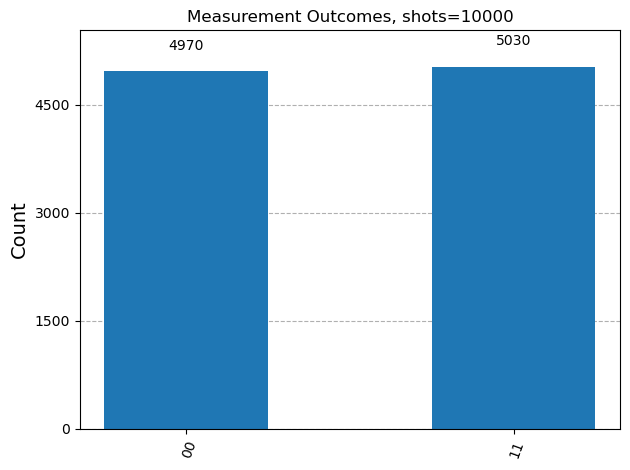

```
{'11': 5030, '00': 4970}
```

```python
# Now, we will execute the circuit on a simulator backend
from unittest import result
from qiskit_aer import Aer
from qiskit import transpile
from qiskit.visualization import plot_histogram
from qiskit.quantum_info import Statevector
from IPython.display import display
from traitlets import Any

N_QUBITS: int = 2
N_SHOTS: int = 10000
SIMULATOR: str = 'aer_sim' \
'ulator'

def print_state_vector(qc: QuantumCircuit, msg: str) -> None:
    state = Statevector.from_instruction(qc)
    print(f"{msg}: {state}")

def create_bell_circuit() -> QuantumCircuit:
    qc = QuantumCircuit(N_QUBITS)
    qc.barrier()
    # print_state_vector(qc, "Barrier 1")

    # apply a Hadamard gate on the first qubit
    qc.h(0)
    # print_state_vector(qc, "Barrier 2")

    # apply a CNOT gate with the first qubit as control and the second as target
    qc.cx(0, 1)
    # print_state_vector(qc, "Barrier 3")
    return qc

def execute_circuit(qc: QuantumCircuit) -> Any | None: # This should return a Counts object from qiskit.result.counts.Counts
    # add measurement to the circuit
    qc.measure_all()

    # transpile the circuit for the simulator backend
    simulator = Aer.get_backend(SIMULATOR)
    compiled_circuit = transpile(qc, simulator)

    # execute the circuit on the simulator backend
    job = simulator.run(compiled_circuit, shots=N_SHOTS)

    # get the results from the job
    result = job.result()

    # get the counts (measurement outcomes)
    counts = result.get_counts(compiled_circuit)

    # plot the histogram of results
    display(plot_histogram(counts, title="Measurement Outcomes, shots="+str(N_SHOTS)))

    return counts

bell_circuit = create_bell_circuit()
counts = execute_circuit(bell_circuit)
print(counts)
```

## General Midterm Questions

Given the variables ($\alpha$, $\beta$, $\gamma$, $\delta$) assume the variables are normalized coefficients- if not, throw an error.

Given the state $\ket{\phi}$:

$$ \ket{\phi} = \alpha \ket{00} + \beta \ket{01} + \gamma \ket{10} + \delta \ket{11} $$

Write a `qiskit` program to generate a circuit $U$ that yields the state $\phi$ after applying $U$. That is, $U \ket{00} = \ket{\phi}$.

> Strategies: use the general rotation gate $U$ gate to compose a larger gate that applies the appropriate rotations in the Q-Sphere.

We can use the properties of the [Schmidt Decomposition](https://en.wikipedia.org/wiki/Schmidt_decomposition) to do this:

```
Generated Circuit:
```

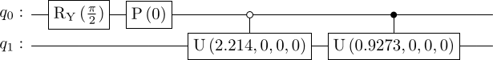

```
Resulting State Vector:
```

$\displaystyle |\phi\rangle = \frac{79}{250} |00\rangle + \frac{79}{125} |01\rangle + \frac{79}{125} |10\rangle + \frac{79}{250} |11\rangle$

```
Estimated Output Probabilities:
|00>: 0.0999 = 9.99%
|01>: 0.3994 = 39.94%
|10>: 0.3994 = 39.94%
|11>: 0.0999 = 9.99%
```

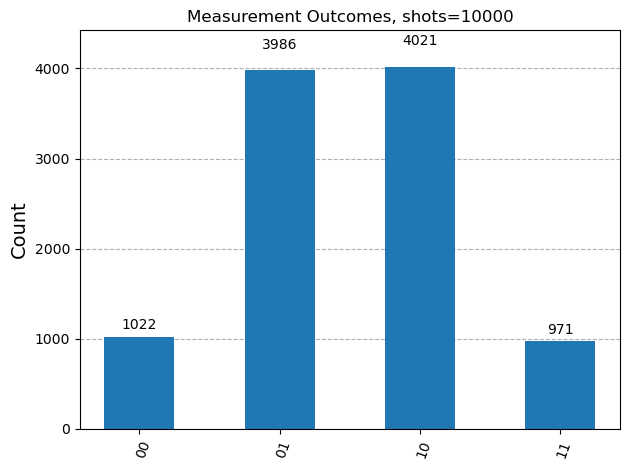

```
Measurement Counts:
{'01': 3986, '10': 4021, '00': 1022, '11': 971}
```

```python
from fractions import Fraction
import numpy as np
import cmath
from qiskit import QuantumCircuit
from qiskit.circuit.library import UGate
from IPython.display import Math, display

def generate_arbitrary_state(alpha, beta, gamma, delta):
    """
    Generates a circuit U such that U|00> = a|00> + b|01> + c|10> + d|11>
    using manual rotation decomposition.
    """

    # 1. VALIDATION & NORMALIZATION
    coeffs = np.array([alpha, beta, gamma, delta], dtype=complex)
    norm = np.linalg.norm(coeffs)

    if not np.isclose(norm, 1.0):
        # Normalize the coefficients
        coeffs = coeffs / norm
        alpha, beta, gamma, delta = coeffs


    # 2. CALCULATE PROBABILITIES FOR Q0
    # Group coefficients by the state of Q0
    # Branch 0 (Q0=0): coefficients alpha, beta
    p0 = np.abs(alpha)**2 + np.abs(beta)**2

    # Branch 1 (Q0=1): coefficients gamma, delta
    p1 = np.abs(gamma)**2 + np.abs(delta)**2

    # Calculate Theta for Q0 Rotation (Ry)
    # Ry(theta) |0> = cos(theta/2)|0> + sin(theta/2)|1>
    # We want cos(theta/2) = sqrt(p0)
    theta_root = 2 * np.arccos(np.sqrt(p0))

    # 3. HELPER: CONVERT VECTOR TO U-GATE ANGLES
    # We need a function to turn a target vector [c0, c1] into U(theta, phi, lambda)
    def get_u_params(c0, c1):
        # Normalize local branch
        local_norm = np.sqrt(np.abs(c0)**2 + np.abs(c1)**2)
        if local_norm == 0:
            return 0, 0, 0, 0 # Dead branch

        c0 = c0 / local_norm
        c1 = c1 / local_norm

        # Convert to Polar
        r0, phase0 = cmath.polar(c0)
        r1, phase1 = cmath.polar(c1)

        # U(theta, phi, lambda) * |0> = cos(theta/2)|0> + e^i(phi)*sin(theta/2)|1>
        # The U gate creates a real coefficient for |0>.
        # We must track the 'global phase' of this branch (phase0) to apply later.

        theta = 2 * np.arccos(r0)
        phi = phase1 - phase0
        lam = 0 # Doesn't affect output when starting from |0>

        return theta, phi, lam, phase0

    # Calculate parameters for the two branches
    theta0, phi0, lam0, phase_branch0 = get_u_params(alpha, beta)
    theta1, phi1, lam1, phase_branch1 = get_u_params(gamma, delta)

    # 4. CONSTRUCT THE CIRCUIT
    qc = QuantumCircuit(2)

    # A. Root Rotation on Q0
    qc.ry(theta_root, 0)

    # B. Phase Correction on Q0
    # We need to fix the relative phase between the |0...> branch and |1...> branch
    # The U-gates we are about to apply assume the first coeff is real,
    # but 'alpha' and 'gamma' might have phases.
    relative_phase = phase_branch1 - phase_branch0
    qc.p(relative_phase, 0) # Apply phase difference to Q1 branch (controlled by Q0=1)

    # Optional: If we cared about Global Phase, we would apply phase_branch0 globally.

    # C. Multiplexed Rotations on Q1
    # We apply U_0 if Q0 is 0, and U_1 if Q0 is 1.

    # Branch 0: Control-0 (Open Control)
    u_gate0 = UGate(theta0, phi0, lam0)
    # Using 'ctrl_state=0' makes it activate when control qubit is 0
    c_u0 = u_gate0.control(1, ctrl_state=0)
    qc.append(c_u0, [0, 1])

    # Branch 1: Control-1 (Standard Control)
    u_gate1 = UGate(theta1, phi1, lam1)
    c_u1 = u_gate1.control(1, ctrl_state=1)
    qc.append(c_u1, [0, 1])

    return qc


# Define un-normalized inputs to test (will be normalized manually for input)
# inputs can be complex numbers.
# Example: Bell State |00> + |11>
# a=1, b=0, c=0, d=1 -> normalized: 1/sqrt(2)
v = [1, 2, 2, 1]
norm_v = np.linalg.norm(v)
params = [x/norm_v for x in v]

try:
    qc = generate_arbitrary_state(*params)
    print("Generated Circuit:")
    display(qc.draw(output='latex', style='default'))

    # Verify statevector BEFORE adding measurements
    from qiskit.quantum_info import Statevector
    final_state = Statevector(qc)
    print("\nResulting State Vector:")
    state_vector = final_state.data.round(3)
    def format_complex(c):
        real = Fraction(c.real).limit_denominator(1000)
        imag = Fraction(c.imag).limit_denominator(1000)

        if np.isclose(imag, 0):
            return f"\\frac{{{real.numerator}}}{{{real.denominator}}}"
        else:
            imag_sign = "+" if imag >= 0 else "-"
            return f"\\frac{{{real.numerator}}}{{{real.denominator}}}{imag_sign}\\frac{{{abs(imag.numerator)}}}{{{abs(imag.denominator)}}}i"

    latex_str = r"|\phi\rangle = " + " + ".join([f"{format_complex(c)} |{i:02b}\\rangle" for i, c in enumerate(state_vector) if not np.isclose(c, 0)])
    display(Math(latex_str))

    # output probabilities
    print("\nEstimated Output Probabilities:")
    for i, amplitude in enumerate(state_vector):
        probability = np.abs(amplitude)**2
        if not np.isclose(probability, 0):
            print(f"|{i:02b}>: {probability:.4f} = {probability * 100:.2f}%")


    # Make a copy for simulation to avoid adding measurements twice
    qc_copy = qc.copy()
    counts = execute_circuit(qc_copy)
    print("\nMeasurement Counts:")
    print(counts)


except Exception as e:
    print(e)
```

# Introductory Quantum Algorithms

> Looks like we are going to do Deustch-Josza Algorithm first, for oracle finding (to demonstrate the quantum speedup).

## Oracles, Deustch, Speedup and Phase Kickback

### What is an oracle?

An oracle is a function that returns an answer-- such as yes or no. The **implementation and logic of the function is *unknown*** to the user.

> In other words, an oracle is a black box.

Given a boolean function $f$, where we are not given the definition, but have the possibility to "probe", or submit an input, and recieve an output, we call such a function an **oracle**.

Our objective could be to learn some property of $f$, or some other task.

Taking this into the quantum realm, we can consider this function to be some **arbitrary unitary**. At it's simplest, it will be a 2-qubit unitary, accepting $x$ and $y$, returning $x$ and $f(x) \oplus y$. We consider $f(x) \oplus y$ to be the **oracle response**.

### Feb. 9 - Oracles, continued

#### Deustch Problem

Given an unknown function $f : \{0, 1 \} \leftarrow \{0, 1 \}$, we want to be able to probe the function and determine if it is *constant or balanced*. In classical computing, we must probe the entire domain of the function in order to analyze it's co-domain (and come up with an answer). However, we can do better in quantum computing.

# Quantum Algorithm Design

Before we can design quantum algorithms, we need to review the basic building blocks of quantum computation, and the tools we have at our disposal.

## Complex Phase and Ampliude

### Euler's Formula

$$ e^{i\theta} = \cos{\theta} + i \sin{\theta} $$

#### Conjugate Form

$$ e^{-i\theta} = \cos{\theta} - i \sin{\theta} $$

### Cosine and Sine in Terms of Exponentials

$$ \cos{\theta} = \frac{e^{i\theta} + e^{-i\theta}}{2} $$ $$ \sin{\theta} = \frac{e^{i\theta} - e^{-i\theta}}{2i} $$

Note that any sine function can be expressed as a phase-shifted cosine function, and vice versa. $$ \sin{\theta} = \cos{\left(\theta - \frac{\pi}{2}\right)} $$

### Polar Form of Complex Numbers

Any complex number can be expressed in polar form as: $$ z = r e^{i\theta} $$ or in trigonometric form as: $$ z = r (\cos{\theta} + i \sin{\theta}) $$ Where $r$ is the magnitude (or modulus) of the complex number, and $\theta$ is the argument (or angle) of the complex number.

### Useful Discrete Phase Landmarks on Unit Circle

- $e^{i0} = 1$
- $e^{i\pi/2} = i$
- $e^{i\pi} = -1$
- $e^{i3\pi/2} = -i$
- $e^{i2\pi} = 1$

## Core Story of a Quantum Algorithm

| Classical Computing | Quantum Computing |
| --- | --- |
| Bits are 0 or 1 | Qubits can be in superposition of 0 and 1 |
| Computation manipulates bits directly | Computation manipulates probability amplitudes and phases of qubits |
| Measurement is deterministic and reads the state of bits | Measurement is probabilistic and collapses qubits to a basis state |

Key differences:

- Quantum algorithms leverage superposition and interference to explore multiple solutions simultaneously.
- Quantum algorithms often require fewer steps than classical algorithms for certain problems (e.g., Shor's algorithm for factoring).
- Quantum algorithms can solve problems that are intractable for classical computers (e.g., simulating quantum systems).

**Crucial Difference:** Classical algorithms manipulate bits directly, while quantum algorithms manipulate the probability amplitudes and phases of qubits, allowing for phenomena like superposition and interference that enable quantum speedups.

## State: Values vs. Amplitudes

In classical computing, the state of a system is represented by bits that can be either 0 or 1 (a switch). In quantum computing, the state of a system is represented by qubits that can be in a superposition of 0 and 1, described by complex probability amplitudes (acts like a wave).

- Classical Bits: Exist in a discrete state. If you have n bits, the system can be in one of $2^n$ possible states, but only one at a time.
- Quantum Qubits: Exist in a continuous superposition (a linear combination) of states. The complex amplitudes determine the probability of measuring a particular state, and can interfere with each other, leading to constructive or destructive interference.
  - For a qubit in a state $\ket{\psi} = \alpha \ket{0} + \beta \ket{1}$, the probabilities of measuring 0 or 1 are given by $|\alpha|^2$ and $|\beta|^2$ respectively, where $\alpha$ and $\beta$ are complex numbers.
  - Remember that the probabilities must sum to 1, so $|\alpha|^2 + |\beta|^2 = 1$.

## Operation: Logic vs. Interference

- Classical computing is all about "flipping switches" (applying logic gates, like AND, XOR, NOT to bits). The operations are deterministic and directly manipulate the state of the bits.
- Quantum computing is all about "manipulating waves" (applying unitary transformations to qubits). The operations are reversible and can create superpositions and entanglement, allowing for interference effects that can amplify correct solutions and cancel out incorrect ones.
- **Quantum Gates**: Unitary transformations (rotations on the Bloch Sphere). By manipulating the phases of the probability amplitudes, quantum algorithms can create interference patterns that enhance the probability of measuring the correct answer.
  - Constructive Interference: When the phases of the amplitudes align, they add together, increasing the probability of measuring that state.
  - Destructive Interference: When the phases of the amplitudes are opposite, they cancel each other out, reducing the probability of measuring that state.

## Result: Reading vs. Collapsing

The way we extract information in quantum computing is the most counterintuitive difference from classical computing.

- Classical Computing: Reading the state of bits is straightforward and deterministic. The bits are in a definite state (0 or 1), and reading them simply reveals that state without altering it.
- Quantum Computing: Measurement collapses the superposition of qubits into a definite state. You don't see the complex amplitudes directly; instead, you get a probabilistic outcome based on the squared magnitudes of the amplitudes, forcing the system to assume one of the basis states.
  - The probability of measuring a specific state is the squared magnitude of its amplitude. For example, if $\ket{\psi} = \alpha \ket{0} + \beta \ket{1}$, the probability of measuring 0 is $|\alpha|^2$ and the probability of measuring 1 is $|\beta|^2$.
  - Each amplitude $\alpha_k = r_k e^{i\theta_k}$ has a magnitude $r_k$ that determines the probability of measuring that state, and a phase $\theta_k$ that can interfere with other states.
- Measurement ignores the phase information, so the outcome is purely probabilistic based on the magnitudes of the amplitudes. This is a fundamental aspect of quantum mechanics and is what allows quantum algorithms to achieve speedups over classical algorithms for certain problems.
- To leverage phase, we use unitary gates to generate interference patterns that amplify the probability of correct answers and suppress incorrect ones, which is a key strategy in quantum algorithm design.

## Measuring Complex Amplitudes

When we measure, we read out probabilities-- achieved by multipliying an amplitude by it's complex conjugate:

- Before measurement, amplitude is squared algebraically: $$ \alpha_k^2 = \left( r_k e^{i\theta_k} \right)^2 \implies \alpha_k^2 = r_k^2 e^{2i\theta_k} $$
- Observe that the phase is doubled and the magnitude is squared, while the value remains complex.
- After measurement, we get a real number (the probability), which is the squared magnitude of the amplitude: $$ \alpha_k = r_k e^{i\theta_k} \quad \Rightarrow \quad |\alpha_k|^2 = \alpha_k \alpha_k^* = r_k^2 $$
- We have some facts about measurement:
  - The phase is cancelled out, and destroys quantum information.
  - However, we can use this magnitude as a probability, which is inherently defined to be a real number between 0 and 1. (At this point this becomes classical information)
  - The amplitude collapses into a real-world probability.

# Quantum Algorithms

## Step 1: Create Parallel Computing Paths

> We can do this by putting all the qubits into superposition, which allows us to explore all possible inputs simultaneously. We do this by applying the Hadamard gate to each qubit, which creates an equal superposition of all possible states.

For a single qubit: $$ H\ket{0} = \frac{1}{\sqrt{2}} (\ket{0} + \ket{1}) $$

For two qubits: $$ H^{\otimes 2} \ket{00} = \frac{1}{2} (\ket{00} + \ket{01} + \ket{10} + \ket{11}) $$

For many (n) qubits: $$ H^{\otimes n} \ket{0}^{\otimes n} = \frac{1}{\sqrt{2^n}} \sum_{x \in \{0,1\}^n} \ket{x} $$ We can simplify this by pulling out a $(-1)^{x \cdot y}$ term, which allows us to express the state as a sum over all possible inputs, with a phase factor that depends on the input. $$ H^{\otimes n} \ket{y}^{\otimes n} = \frac{1}{\sqrt{2^n}} \sum_{x \in \{0,1\}^n} (-1)^{x \cdot y} \ket{x} $$

- Creates the level quantum horizon
- Creates parallel computing paths, which is the first step in achieving quantum speedup.
- Amplitudes have equal magnitude
- All phases are aligned

## Step 2: Encode the Problem into the Phase

### Oracle or Phase Encoding

- Two types of problem encoding:
  1. **Boolean Oracle**: Encodes the problem into the phase of the quantum state, allowing us to leverage interference to amplify correct answers and suppress incorrect ones.
  2. **Hamiltonian Encoding**: Encodes the problem into the energy levels of a quantum system, which can be used for algorithms like Quantum Phase Estimation and Quantum Simulation.
- Pauli Gates, mutli-controlled phase gates and other unitary gates can be used to encode the problem into the phase of the quantum state.

### Boolean Oracle

- Used for search algorithms and decision problems.
- Encodes a function $f(x)$ into the phase of the quantum state, such that $$ U_f \ket{x} = (-1)^{f(x)} \ket{x} $$
- This allows us to create interference patterns that amplify the probability of measuring the correct answer, without revealing the function itself.
- Essentially, this provides a mathematical description of "finding the needle in a haystack".

### Hamiltonian Encoding

- Used for problems in quantum simulation and optimization.
- Encode teh contraints of a molecule or a system into a mathematical operator called a Hamiltonian, which describes the energy of the system.
- The phases accumulate at different speeds depending on the energy of each state.
- We aim to find the lowest energy state, which corresponds to the optimal solution of the problem.

Key point: Step 2 does not affect amplitudes, but only the phases. This is crucial for leveraging interference in the next step.

## Step 3: Interference Reshapes the Problem into Phase

- Apply Hadamard gates first to rotate the landscape back into a state where we can manipulate the average of the amplitudes.

> Our phase changes that we made are now perceptible as we shift back to a measureable basis.

> We have a diffusion operator with three distinct layers. Think of this like a "a sandwich of gates" or "applying mixing gates".

### Layer 1: Horizon - Hadamard

### Layer 2: Marker - Inversion Filter

- Inversion filter - use Pauli X gates on all qubits so that teh all-zero state represents the mean; the average is now the pivot point for the inversion.

### Layer 3: Reshape - Multi-Controlled Phase Gates

- Apply a phase flip (Z gate) to one specific state.
  - This has the effect of creating mathematical interference, which "identifies the needle in the haystack".
- Repeat the X and H gates to return the landscape to the original basis, but with the amplitudes reshaped by the interference.

## Step 4: Measure the State and Extract the Engineered Bias

- Measurement **DOES NOT COMPUTE** the answer, but instead reads out the probabilities of the engineered state.
- This reveals the result of the interference pattern we applied.

> At this point, desired states now have large amplitudes, while undesired states have small amplitudes.

# The Universal Quantum Algorithm Template

**Superposition**: Create many parallel computing paths by putting qubits into superposition.

**Phase Encoding**: Write the porblem into the phase of the quantum state, without affecting the amplitudes.

**Interference**: Mix amplitudes to reshape the probability landscape, amplifying correct answers and suppressing incorrect ones.

**Measurement**: Sample from the engineered probability distribution to extract the answer.

> Quantum computing gets it's speedup from precisely engineering the interference patterns to amplify the probability of correct answers, while suppressing incorrect ones. This is achieved through careful design of the quantum circuit, leveraging superposition and phase manipulation to create constructive interference for the desired solution.

In short, a quantum algorithm is a carefully engineerd sequence of unitary operations that encodes problem structure into relative phases, and then uses interference to transform thoses phases into amplitude differences, and then extracts the result through measurement.

# Grover's Algorithm

Problem: **Unstructured Search**. Given a search space $ S = \{ 0, 1, \dots, N-1 \}$, with oracle function $ f = \{0, 1, \dots, N-1 \} \rarr{} \{0, 1\}$, where there is exactly *one* $x$ such that $f(x) = 1$. We want to find $x$.

Approach: We want to leverage interference (via amplitude amplifciation) to "tease" out the appropriate value from a superposition of the entire search space. We also need to design a *phase oracle* that will invert (say, apply X) the term in the superposition that satisfies $f(x) = 1$. We then need to design a gate to amplify this "marked" value.

## Phase Oracle

Let $x_1, x_2, \dots, x_n \in \{ 0,1 \}, f: \{0, 1 \}^n \rarr \{0, 1\}$, and $\ket{x} = \ket{x_1 x_2 \dots x_n}$.

Using this, we define an operator $U$ (from [Wikipedia](https://en.wikipedia.org/wiki/Grover%27s_algorithm?useskin=vector#Problem_description)):

[figure not shown]

## Diffuser Gate

This gate applies the inversion about the mean (this does the amplitude amplification).

More specifically, D (the diffusion gate) must update amplitudes to $\alpha^\prime_x = 2a - \alpha_x$.

In the general case, $ a = \frac{1}{N} \sum_{x \in S}\alpha_x$.

To do this, we do:

$$ D = H^{\otimes{} n} \left(2 \ket{0}^{\otimes{} n} \bra{0}^{\otimes{} n} - I^{\otimes{} n} \right) H^{\otimes n} $$

Note to the reader: At this point I changed gears in how I consumed the lecture content: instead of taking notes during lecture, I would review the lecture content after class, and then take notes on it. This is because I found that I was missing a lot of the content during lecture, and I wanted to be able to review it in more detail after class.

Note that the below content is far more reflective as well.

# Week 9 (Lecture 15/16)

These lectures were where the course started to feel much more structural to me. Up to this point I was thinking mostly in terms of gates and circuits. Here, the focus shifted toward operators, eigenvectors, and the basis that makes an operator easy to understand.

## Eigenvalues and the spectral theorem

For a linear operator $A$, an eigenvector $\ket{v}$ satisfies

$$ A\ket{v} = \lambda \ket{v} $$

for some scalar $\lambda$.

What helped me here is thinking of eigenvectors as the directions a transformation refuses to mix away. The operator may stretch the vector, shrink it, or attach a phase, but it does not send it off into some unrelated direction.

For normal operators, the spectral theorem gives the clean decomposition

$$ A = VDV^{\dagger} = \sum_k \lambda_k \ket{\phi_k}\bra{\phi_k}. $$

This seems like one of the most useful facts in the whole course:

- Hermitian operators have real eigenvalues, so they model observables.
- Unitary operators have eigenvalues on the unit circle, so they naturally carry phase.
- Measurement can be understood as projection onto an eigenbasis.

> My main takeaway: if I can move into the right basis, a messy operator often becomes almost trivial.

## Matrix exponentials

The next important piece was understanding why exponentials of operators keep appearing. If $H$ is Hermitian, then

$$ U(t) = e^{-itH} $$

is unitary, so it can describe valid time evolution.

And if

$$ H\ket{\phi_k} = E_k\ket{\phi_k}, $$

then

$$ e^{-itH}\ket{\phi_k} = e^{-itE_k}\ket{\phi_k}. $$

So the eigenvectors stay the same, but each one picks up phase at a rate determined by its eigenvalue. That was the point where Hamiltonian simulation started to feel less mysterious to me: time evolution is basically phase engineering in the eigenbasis.

Coming back to this section later, I found this idea really is central to quantum computing: QPE, Hamiltonian simulation, and QAOA all lean on this same principle.

# Week 10/11 (Lecture 18/19)

## Quantum Fourier Transform (QFT)

These slides helped me see the QFT as something more natural than just “the big transform from Shor's algorithm.” The main idea is that periodic structure shows up everywhere in quantum algorithms: hidden periods, amplitude oscillations, eigenphases, and so on.

For $N = 2^n$, the QFT acts as

$$ \text{QFT}\ket{x} = \frac{1}{\sqrt{N}} \sum_{k=0}^{N-1} \omega_N^{xk}\ket{k}, \qquad \omega_N = e^{2\pi i/N}. $$

What I found especially helpful was the cyclic-shift viewpoint:

$$ S\ket{x} = \ket{x+1 \bmod N}. $$

The Fourier basis is the eigenbasis of this shift operator, so the QFT diagonalizes shift or periodicity structure. Essentially, it converts “where things are” into “how fast they oscillate.”

This reminds me a lot of ECE310. In signals and systems, the DFT rewrites a discrete-time signal in terms of complex exponential basis functions, so we can analyze the signal by its frequency content instead of by its samples in time. The Fourier basis in quantum computing feels very similar: instead of rewriting a time-domain signal, we rewrite a quantum state’s amplitude vector in a phase/frequency basis. So, in both courses, the Fourier basis is really a change of basis that makes periodic structure easier to see.

> In short: the QFT is basically a change of basis that makes periodic information easy to read.

## Quantum Phase Estimation (QPE)

QPE starts with an eigenstate $\ket{\psi}$ of a unitary $U$:

$$ U\ket{\psi} = e^{2\pi i\phi}\ket{\psi}. $$

The goal is to estimate the phase $\phi$.

The algorithm, at a high level, is:

1. Put the counting register into equal superposition.
2. Apply controlled powers $U, U^2, U^4, \dots$.
3. Use phase kickback to write the phase information onto the counting register.
4. Apply the inverse QFT.
5. Measure an approximation of the binary digits of $\phi$.

What finally clicked for me is that the inverse QFT is not creating the answer. After the controlled powers, the counting register is already in a Fourier-type phase state; the inverse QFT just decodes it into an ordinary bit string.

A useful intermediate picture is

$$ \frac{1}{\sqrt{2^m}} \sum_{k=0}^{2^m-1} e^{2\pi i k\phi}\ket{k}, $$

which is exactly the kind of phase pattern the inverse QFT knows how to decode.

If the unitary is built from a Hamiltonian, $U = e^{-itH}$, then estimating phase becomes estimating energy. That is why QPE keeps coming back in chemistry and simulation.

# Week 11/12 (Lecture 20/21)

This week we really showed the power of Quantum Algorithms, and how we can use them to solve real (and NP-hard) problems. This was neat.

## QUBO and Ising form

A lot of hard classical problems can be written using binary decision variables. The examples in these slides were things like MaxCut, Vertex Cover, Graph Colouring, and Dominating Set.

The standard QUBO form is

$$ f_Q(x) = x^T Q x, \qquad x_i \in \{0,1\}. $$

If the original problem has constraints, the trick is to fold them into the objective with penalty terms. So invalid solutions are still present mathematically, but they become too expensive to be attractive.

Then we convert binary variables into spin variables:

$$ x_i = \frac{1-z_i}{2}, \qquad z_i \in \{-1,1\}. $$

After promoting the $z_i$ to Pauli-$Z$ operators, we get a cost Hamiltonian $H_C$ satisfying

$$ H_C\ket{x} = C(x)\ket{x}. $$

Because $H_C$ is diagonal in the computational basis, exponentiating it just attaches cost-dependent phase:

$$ e^{-itH_C}\ket{x} = e^{-itC(x)}\ket{x}. $$

That was a really nice moment for me, because it tied optimization back to the same “encode useful structure into phase” chain of thought from earlier lectures.

## QAOA

QAOA alternates a cost Hamiltonian with a mixer Hamiltonian:

$$ \ket{\psi_p(\boldsymbol{\gamma}, \boldsymbol{\beta})} = \left( \prod_{j=1}^{p} e^{-i\beta_j H_M} e^{-i\gamma_j H_C} \right) H^{\otimes n}\ket{0}^{\otimes n}. $$

My understanding of the pieces is:

- $H_C$ marks good and bad solutions through phase.
- $H_M$ moves amplitude around the search space so we do not get stuck on one basis state.
- A classical optimizer tunes the parameters to lower the expected cost.

The lectures also made the hardware distinction clearer:

- annealers are very natural for QUBO / Ising formulations,
- gate-based machines use circuits built from cost and mixer layers.

It would be really nice to talk about hardware some more here (especially compared to Rogerio's lectures, which introduced hardware first to motivate the development of software).

# Week 12/13 (Lecture 22-24)

## Applications and the discovery cycle

These last lectures were probably the biggest shift in perspective for me. The point was no longer just “here is another algorithm,” but “why do these eigenvalues and phases matter in practice?”

The big idea was a move from approximation to measurement. From what we covered, it seems that for a lot of chemistry and materials work, classical methods solve approximations to the actual physics/chemistry because the problems are too computationally expensive to solve directly. The quantum-computing approach is to prepare a physical system that follows the same physics, let it evolve, and measure it.

The slides compared a classical discovery loop

- approximate model
- AI/ML trained on approximate data
- generative design
- lab validation

with a quantum-enabled loop

- quantum simulation
- higher-fidelity data
- AI / generative proposal
- quantum validation

If I learned anything from lecture, it's that we ALWAYS keep the human in-the-loop. (Hausi, I think I stumbled over my words in lecture that day. I meant to say that the time it takes to theoretically design and verify a proposed solution is reduced, not that the human is actually removed from the process. Oops!)

## Why QPE shows up here

If

$$ H\ket{\phi_k} = E_k\ket{\phi_k} $$

and

$$ U = e^{-itH}, $$

then the phase measured by QPE is directly related to the energy $E_k$. That is why the phrase "phase is energy" kept showing up in the slides, and honestly I think that is a pretty good summary.

## Grad-presentation takeaways

A few application patterns showed up repeatedly:

- Traffic optimization: route choices, congestion penalties, and validity constraints can be written as QUBOs, which makes annealing or QAOA-style methods natural.
- Protein folding: low-energy structure search fits nicely with Hamiltonian thinking and variational methods such as VQE.
- Graph colouring: a pure Grover-style approach gets ugly fast because of ancilla and depth, so QUBO + QAOA looks much more practical. There seems to be a good amount of research to do further in this space, based on Chuan's analysis of the field. I realized here that I need to take CSC 320 ASAP to get a better handle on the basics of computation and working on difficult problems. (I was hoping to take it this summer with Ulrike, but it looks like I will be on a co-op term instead.)

## Part 2 reflection

Part 1 of this notebook was mostly me learning the language of quantum computing. Part 2 felt more like learning the backbone of it.

The same ideas kept reappearing in deeper forms:

- states became eigenstates,
- gates became exponentials of operators,
- phase became the place where useful information lives,
- applications became questions of encoding the right Hamiltonian.

That repetition was actually reassuring. By the end of the course, the subject felt much less like a pile of separate tricks and much more like one consistent story about basis changes, phase engineering, interference, and measurement.

## Part 2 Questions (From Assignment Definition)

1. In your own words, describe the Quantum Fourier Transform (QFT) algorithm. How is QFT used in quantum computing?

The QFT algorithm is a change of basis that takes a quantum state from the computational basis to the Fourier basis. It works by generating a superposition of all possible states, and rotating them in a specific way to achieve the correct phases (which encode the frequency information). We apply a swap gates at the end to ensure the correct ordering. This allows us to analyze periodic structure in the state, which is useful for algorithms like Shor's algorithm for factoring and Quantum Phase Estimation (QPE). This can also be extended to a field of applications in signal processing, where the QFT can be used to analyze the frequency content of a quantum state.

2. In your own words, describe the Quantum Phase Estimation (QPE) algorithm. How is QPE used in quantum computing?

The QPE algorithm is a method for estimating the phase of an eigenvalue of a unitary operator. It is used in quantum computing to estimate the energy levels of a Hamiltonian, which is crucial for many quantum algorithms and applications including chemistry and materials science, factoring, optimization, and more. The algorithm works by preparing a counting register in superposition, applying controlled powers of the unitary operator, and then using the inverse QFT to decode the phase information into a binary string that can be measured. This allows us to extract information about the eigenvalues of the operator, which can be used to solve various problems.

3. For you, what was the most challenging part of understanding Grover's algorithm and why?

For me, the hardest part of Grover’s algorithm was understanding the diffuser, especially why “inversion about the mean” actually amplifies the marked state. The oracle itself is not too bad conceptually, but the geometric picture of repeated reflections acting like a rotation in a 2D subspace took me longer to internalize. I think it was challenging because the circuit looks simple, but the reason it works is much less obvious than in something like Deutsch or teleportation.

4. Which is your favourite quantum algorithm and why?

It's still Shor's Algorithm. I have a soft spot for cybersecurity and cryptography, and Shor's algorithm is the one that really opened my eyes to the potential of quantum computing. The fact that it can factor large integers exponentially faster than the best-known classical algorithms is just mind-blowing, and it has such profound implications for the security of our digital world. Plus, the way it combines quantum Fourier transform and phase estimation is really elegant. The tools we learned in this course allowed me to better understand how it works, and I just find it even more fascinating now.

5. What is the role of eigenvalues and eigenstates (eigenvectors) in quantum computing?

The Eigenstructure of a problem are central to quantum computing. The Eigenstates are the "natural" states of a system, and the eigenvalues tell us how those states evolve under certain operations. Eigenstates are the "natural" basis states of a linear operator, and the associated eigenvalues tell us how the operator acts on those states.

We can take this idea further when considering Hermitian operators, which have the eigenvalues as a "list" of potential measurement outcomes. QPE uses this directly to estimate the eigenvalues of a unitary operator, and QAOA uses the eigenvalues of the cost Hamiltonian to guide the optimization process.

6. Summarize the decomposition strategies presented in class for developing hybrid quantum-classical systems.

The main decomposition strategies from class seemed to be: classical preprocessing and problem reformulation first, then a quantum core for the hard part, then classical post-processing or optimization around that core. In the optimization lectures, the loop presented was: problem definition -> QUBO/HUBO -> Ising/spin form -> cost Hamiltonian -> unitary/gate sequence -> variational feedback loop.

7. Which one is your favourite decomposition strategy? Describe this strategy in detail.

I like the feedback loop strategy, in particular the one used in QAOA, as there is a clear division of responsibilities between the quantum and classical domains. The quantum part is responsible for preparing a parameterized state that encodes the problem structure (via the parameterized cost and mixer layers), while the classical part is responsible for tuning the parameters to reach an optimal solution.

8. Write a summary of the different quantum applications presented by the graduate students.

Aden + Joyce: Traffic Flow Optimization. They used a QUBO formulation to model the problem, and then applied QAOA to find optimal routing solutions that minimize congestion. This seems to be a great example of how quantum algorithms can be applied to real-world optimization problems, and potentially be deployed in a practical, real-time scenario.

Chuan: Graph Colouring. He used a QUBO formulation to model the graph colouring problem, and explored various methods to optimize the runtime and resource requirements of finding a solution. This is a nice example of how quantum algorithms can be applied to combinatorial optimization problems, and how there is still a lot of research to be done in this area to make it more practical.

Naomi: Protein Folding. She used a Hamiltonian formulation to model protein structures and applied variational algorithms to understand biological systems, identify disease causes, design new drugs, and further advance genetic research. This is a great example of how quantum algorithms can be applied to problems in chemistry and biology, and how they can potentially lead to breakthroughs in understanding complex systems. This also demonstrated the inherently interdisciplinary nature of computing in general.

Iuliiana: Quantum State Distribution Optimization via Quantum State Encryption. I didn't fully understand this one, but from the cited paper, it seemed that the idea was that we can distribute multiple copies of a quantum state to multiple parties, and when appropriate, a decryption key can be used (by a single party to follow the no-cloning theorem) to allow reconstruction of the original state. This will likely be important for quantum communication when we have large-scale quantum networks, and we want to be able to send states to multiple processing platforms, and only process on the first avaliable platform.

9. Which applications inspired you the most? Describe this application in more detail. Please note graduate students who have presented an application cannot write about the application they present for their grad project.

Of the applications presented, I found the traffic flow optimization one to be the most inspiring, and naturally intuitive to me. This intuition comes from my previous experience with real-time systems, particularly in ECE455 (real-time operating systems), where we have to manage finite resources effectively. In traffic flow optimization, the "finite resource" is the road network, and the "tasks" are the cars trying to get from point A to point B. The goal is to minimize congestion, which is analogous to minimizing latency in a real-time system.

In short, we modeled the traffic flow problem as a QUBO, where the decision variables represented route choices, and the objective function included congestion penalties and validity constraints (such as two cars occupying the same road segment at the same time). By applying QAOA, we were able to find optimal routing solutions (for each car and time step) that minimized congestion across the network.

This is particularly exciting because the problems explodes in complexity as the number of cars and road segments increases, making it a great candidate for quantum optimization algorithms. Related work on decomposing systems into sub-networks and applying quantum algorithms to each sub-network also seems promising for scaling this approach to larger, real-world traffic systems.

10. Did you use Generative AI tools (e.g., ChatGPT, Gemini, Copilot, or Perplexity) in the learning journey of this course? If so, what was your experience?

I used a combination of IDE-specific tools (like GitHub Copilot) and general-purpose tools (like Gemini and NotebookLM) to help me with the course. I used each of these tools for specific purposes:

- GitHub Copilot: I used this for code completion and to remind me of syntax and common patterns in Python and Qiskit/Pennylane.
- Gemini: I used this for general questions about quantum computing concepts, to help me understand the material better, and to get explanations in different ways when I was stuck. I followed Hausi's adivce to stick to a 'Quantum Context', which really helped me get more relevant and accurate responses. I also found that asking Gemini for sources and examples directly was helpful for finding additional resources to study from.
- NotebookLM: I used this to help me organize my notes and to generate summaries of the lectures and readings. This tool also generated podcasts from my notes and the lecture slides, which I found helpful for reviewing the material while I commuted to class or went for walks.
11. What topics, methods, and tools of this course did you add already or are you going to add to your résumé?

As a result of this course, I have added the following topics, methods, and tools to my résumé:

- Quantum SDKS: Qiskit / Pennylane
- Scientific Computing: NumPy, SciPy, Matplotlib
- Tools: Jupyter Notebooks, Git, Github, Jupyter Notebook, Anaconda, LaTeX
- Modeling: QUBO + Ising Form, Hamiltonian Formulation, Variational Algorithms (VQE, QAOA)

I'm not sure I should explicitly list quantum algorithms on my résumé, especially for non-quantum related positions.

12. What have been your personal insights, aha moments, or epiphanies you experienced in the second part of your quantum learning journey?
- The idea that quantum algorithms are really about engineering interference patterns to amplify correct answers and suppress incorrect ones was a big aha moment for me. It helped me see the common thread between different algorithms and understand why they work.
- The fact that the QFT is basically a change of basis that makes periodic information easy to read was another big insight. It helped me understand why the QFT is so useful in algorithms like Shor's and QPE, and how it relates to the Fourier transform in classical signal processing.
- The realization that the inverse QFT in QPE is not creating the answer, but just decoding the phase information that is already there was also a big epiphany for me. It helped me understand the algorithm better and see how the pieces fit together.

# Bibliography

[1] B. Zygelman, A First Introduction to Quantum Computing and Information. in Undergraduate Topics in Computer Science. Cham: Springer International Publishing, 2025. doi: 10.1007/978-3-031-66425-0.

[2] M. A. Nielsen, Quantum computation and quantum information. Cambridge; Cambridge University Press, 2000.

[3] K. Purbhoo, “Notes on Tensor Products and the Exterior Algebra”.

[4] H. Muller, U. Stege, and P. Angara, SENG 457 / CSC 557 lecture slides, University of Victoria, Spring 2026.

## Useful Resources

- [IBM Quantum Composer](https://quantum.cloud.ibm.com/composer) - Visual circuit design and testing
- [Qiskit Textbook](https://qiskit.org/learn) - Comprehensive quantum computing tutorials
- [Xanadu Codebook](https://pennylane.ai/codebook) - Interactive quantum programming exercises
- [Quantum Algorithm Zoo](https://quantumalgorithmzoo.org/) - Comprehensive catalog of quantum algorithms